# Lab 6: Intro to Inference, Confidence Intervals, and Significance

Ednita J Tavarez-Jimenez

## Sample Standard Error Function

**Q1: Show the R code you used to define your sse_mean() function. Include the following line before your function definition:**

```r
require(palmerpenguins)
rm(list = ls())
x <- penguins$bill_depth_mm
print(x)
```

[output not shown]

```r
sse_mean = function(x)
{

sd(x)
  is.na(x)
x2 <- x[!is.na(x)]
length(x2)
sd(x2)
sse_mean = (sd(x2)/sqrt(length(x2)))
return(sse_mean)
  }
sse_mean(penguins$body_mass_g)
```

```
## [1] 43.36473
```

```r
sse_mean(mtcars$mpg)
```

```
## [1] 1.065424
```

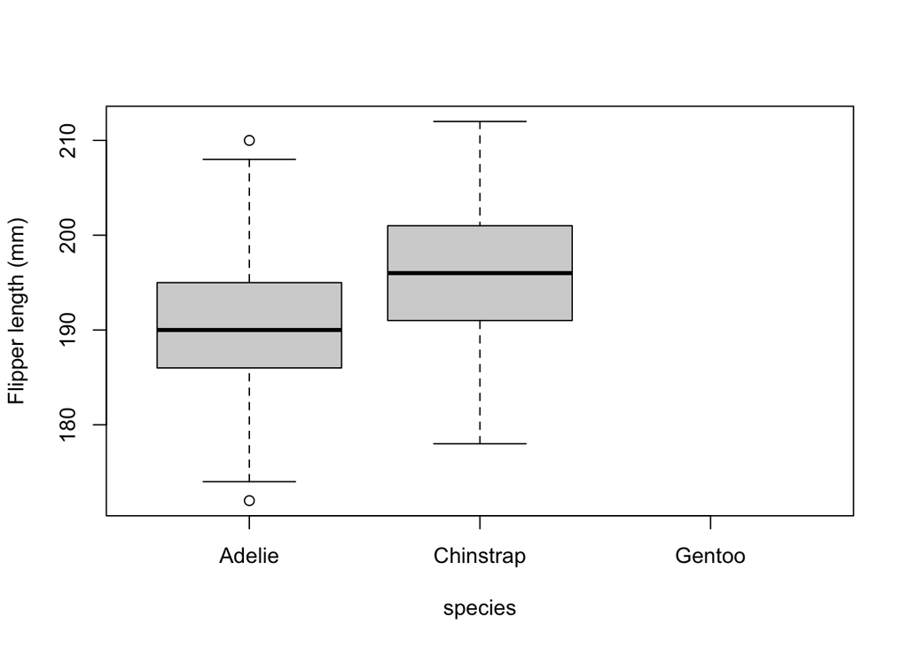

```r
penguins = subset(penguins, species != "Gentoo")
boxplot(
  flipper_length_mm ~ species, data = penguins,
  ylab = "Flipper length (mm)")
```

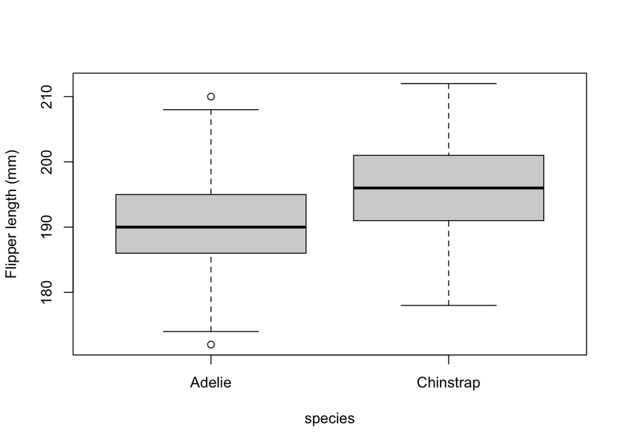

```r
dat_pen = droplevels(subset(penguins, species != "Gentoo"))
{
  boxplot(
    flipper_length_mm ~ species, data = dat_pen,
    ylab = "Flipper length (mm)")
}
```

## Two Group Resampling

**Q2: Show the code you used to define your two_group_resample_diff() function.**

```r
agg_means = aggregate(
  flipper_length_mm ~ species,
  data = penguins,
  FUN = "mean",
  na.rm = TRUE)
diff_observed = diff(agg_means[, 2])

agg_means
```

```
##     species flipper_length_mm
## 1    Adelie          189.9536
## 2 Chinstrap          195.8235
```

```r
diff_observed
```

```
## [1] 5.869887
```

```r
x = dat_pen$flipper_length_mm
n_1 = 68
n_2 = 152


two_group_resample_diff = function(x, n_1, n_2)
{
  x2 <- x[!is.na(x)]
dat_1 = sample(x2, n_1, replace = TRUE)
dat_2 = sample(x2, n_2, replace = TRUE)

diff_mean =
  mean(dat_1, na.rm = TRUE) - mean(dat_2, na.rm = TRUE)

return(diff_mean)
}

#print(c(observed = diff_observed, mean = diff_mean))

set.seed(54321)
two_group_resample_diff(dat_pen$flipper_length_mm, 68, 152)
```

```
## [1] -1.426471
```

**Q3: Does your function perform Monte Carlo or bootstrap resampling, i.e. does it simulate a null or an alternative hypothesis? You may want to review your answer after you complete the rest of the lab questions.**

It performs a Monte Carlo and simulates a null hypothesis.

## Resample Flipper Lengths

**Q4: Create a histogram of the resampled differences of means.**

```r
set.seed(5)
n = 200
mean_differences = c()
for (i in 1:n)
{
  mean_differences = c(
    mean_differences,
    two_group_resample_diff(dat_pen$flipper_length_mm, 68, 152)
  )
}
sum(abs(mean_differences) >= diff_observed)
```

```
## [1] 0
```

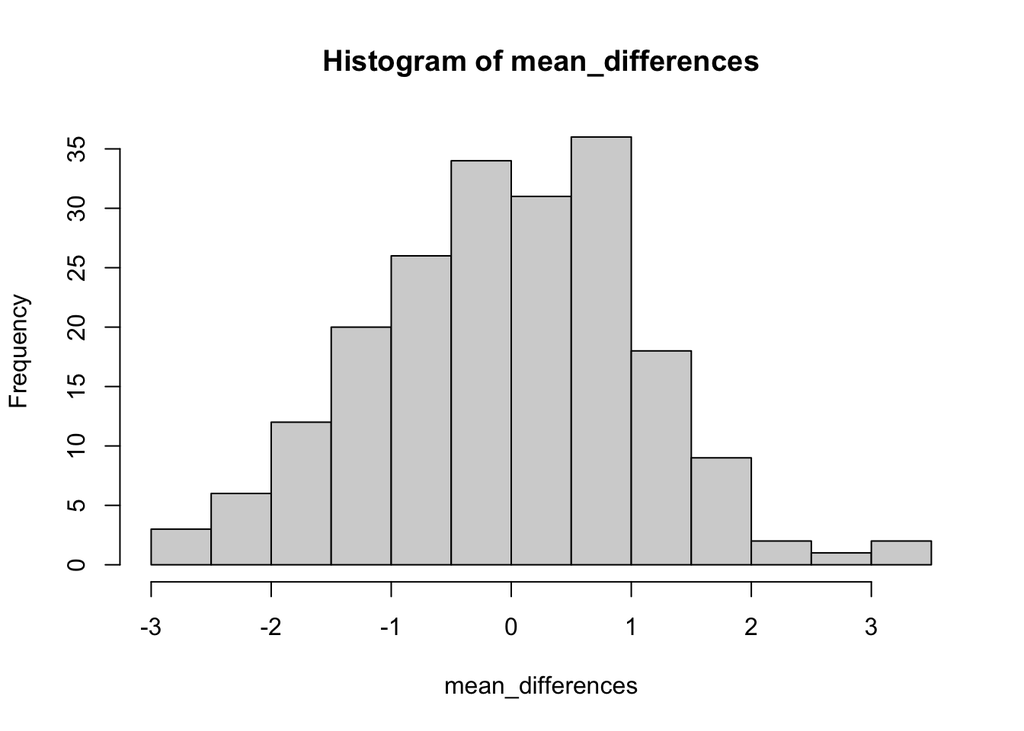

```r
hist(mean_differences)
```

**Q5: How many of your resampled differences of means had a magnitude greater than 5.8?**

0 samples had resample differences of means greater than 5.8

## Resampling and p-values

**Q6: Given a p value of less than 1 per 10 million, how many simulations do you think you would have to do to see a difference in mean flipper length equal to or greater than 5.8 mm?**

The p-value of 6.049e-08 is so small that you would have to run thousand if not millions of simulations to see any significant extremes.

## Resampling a different variable

```r
require(palmerpenguins)
rm(list = ls())
x <- penguins$bill_depth_mm
print(x)
```

[output not shown]

```r
sse_mean = function(x)
{

sd(x)
  is.na(x)
x2 <- x[!is.na(x)]
length(x2)
sd(x2)
sse_mean = (sd(x2)/sqrt(length(x2)))
return(sse_mean)
  }
```

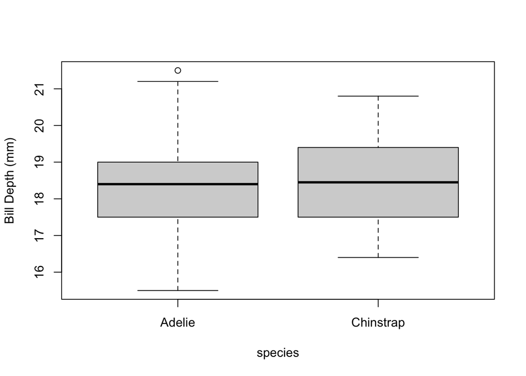

```r
dat_pen = droplevels(subset(penguins, species != "Gentoo"))
{
  boxplot(
    bill_depth_mm ~ species, data = dat_pen,
    ylab = "Bill Depth (mm)")
}
```

```r
agg_means = aggregate(
  bill_depth_mm ~ species,
  data = dat_pen,
  FUN = "mean",
  na.rm = TRUE)
diff_observed = diff(agg_means[, 2])

agg_means
```

```
##     species bill_depth_mm
## 1    Adelie      18.34636
## 2 Chinstrap      18.42059
```

```r
diff_observed
```

```
## [1] 0.07423062
```

```r
#Group means
table(dat_pen$species)
```

```
##
##    Adelie Chinstrap
##       152        68
```

```r
x = penguins$bill_depth_mm
n_1 = 152
n_2 = 68


two_group_resample_diff = function(x, n_1, n_2)
{
  x2 <- x[!is.na(x)]
dat_1 = sample(x, n_1, replace = TRUE)
dat_2 = sample(x, n_2, replace = TRUE)

diff_mean =
  mean(dat_1, na.rm = TRUE) - mean(dat_2, na.rm = TRUE)


return(diff_mean)
}
set.seed(54321)
two_group_resample_diff(dat_pen$bill_depth_mm, 68, 152)
```

```
## [1] 0.3755031
```

```r
t.test(dat_pen$bill_depth_mm ~ dat_pen$species)
```

```
##
##  Welch Two Sample t-test
##
## data:  dat_pen$bill_depth_mm by dat_pen$species
## t = -0.43771, df = 137.75, p-value = 0.6623
## alternative hypothesis: true difference in means between group Adelie and group Chinstrap is not equal to 0
## 95 percent confidence interval:
##  -0.4095657  0.2611044
## sample estimates:
##    mean in group Adelie mean in group Chinstrap
##                18.34636                18.42059
```

```r
#print(c(observed = diff_observed, mean = diff_mean))
```

**Q8: Report the group means and difference between the means.**

The group means are: Adelie = 18.346 & Chinstrap = 18.42059. The different between means is .0742.

**Q9: Interpret the p-value from the t-test output in plain,non-technical English that a non-statistician would understand.**

A p-value is the probability is a number that assumes the results does not have a big difference when you questioning something is correct. In this case, since the p-value = 0.6623, this means that I will see higher numbers more than smaller because my p-value is >.05

**Q10 (2 pts.): How many differences in means were greater than diff_crit?

```r
#set.seed(5)
n = 1000
mean_differences = c()
for (i in 1:n)
{
  mean_differences = c(
    mean_differences,
    two_group_resample_diff(dat_pen$bill_depth_mm, 152, 68)
  )
}
sum(abs(mean_differences) >= diff_observed)
```

```
## [1] 679
```

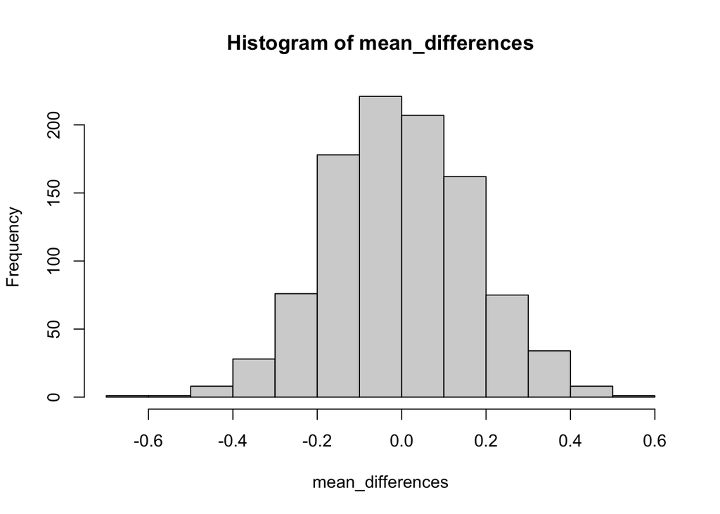

```r
hist(mean_differences)
```